# Process_Analysis

This is R Notebook present a process analysis of 746 completed, fully validated, and archived projects in the HOT Tasking Manager (HOT-TM) over the past two years. The process is analised from four perspectives:

0. Project profiling
1. Control flow
2. Time
3. Organisation
4. Outcome

Process discovery was performed using bupaR, a suite of open-source R packages for business process data analysis.

```r
# Import required libraries
suppressWarnings({
#install.packages("reshape2")
#install.packages("gt")
library(bupaverse)
library(reshape2)
library(gt)
library(scales)
library(readr)
library(dplyr)
library(magrittr)
library(ggplot2)
library(Hmisc)
library(gamlss)
})
```

# Read event data

The log containing only initial tasks (“initial_tasks.csv”) is used in 1) Control flow, 2) Time, 3) Organisation sections, where a clean view of the process is required.

```r
event_log_df <- read.csv("initial_tasks.csv", stringsAsFactors = FALSE, sep = ",")
event_log_df <- event_log_df %>%
  convert_timestamps(columns = c("start", "complete"), format = ymd_hms) %>%
  activitylog(case_id = "taskId", activity_id = "action", resource_id = "actionBy", timestamps = c("start", "complete"))
```

```r
head(event_log_df)
```

```
# Log of 12 events consisting of:
2 traces
5 cases
6 instances of 2 activities
1 resource
Events occurred from 2021-12-01 04:45:26 until 2021-12-01 04:54:13

# Variables were mapped as follows:
Case identifier:        taskId
Activity identifier:        action
Resource identifier:        actionBy
Timestamps:     start, complete
```

| X | taskId | action | actionBy | start | complete | .order |
| --- | --- | --- | --- | --- | --- | --- |
| 0 | 11875_33 | LOCKED_FOR_MAPPING | fajarramadhana | 2021-12-01 04:45:26 | 2021-12-01 04:46:29 | 1 |
| 1 | 11875_72 | LOCKED_FOR_MAPPING | fajarramadhana | 2021-12-01 04:46:37 | 2021-12-01 04:47:15 | 2 |
| 2 | 11875_85 | LOCKED_FOR_MAPPING | fajarramadhana | 2021-12-01 04:47:24 | 2021-12-01 04:49:46 | 3 |
| 3 | 11875_42 | LOCKED_FOR_MAPPING | fajarramadhana | 2021-12-01 04:49:53 | 2021-12-01 04:53:22 | 4 |
| 4 | 11875_42 | MAPPED | fajarramadhana | 2021-12-01 04:53:23 | 2021-12-01 04:53:23 | 5 |
| 5 | 11875_29 | LOCKED_FOR_MAPPING | fajarramadhana | 2021-12-01 04:53:55 | 2021-12-01 04:54:13 | 6 |

# 0. Project profiling

Read list of projects to be analised

```r
projects <- read.csv("projects.csv", stringsAsFactors = FALSE, sep = ",")
head(projects)
```

|  | projectId | country | country_code | difficulty | totalTasks | quantile | region |
| --- | --- | --- | --- | --- | --- | --- | --- |
| 1 | 11875 | Nepal | NP | EASY | 89 | Q1 | AP |
| 2 | 11884 | Philippines | PH | EASY | 194 | Q2 | AP |
| 3 | 11890 | Guatemala | GT | EASY | 734 | Q4 | LAC |
| 4 | 11891 | Guatemala | GT | EASY | 606 | Q4 | LAC |
| 5 | 11892 | Nigeria | NG | EASY | 600 | Q4 | WNA |
| 6 | 11893 | Tanzania | TZ | MODERATE | 2726 | Q4 | ESA |

Frequency of projects according to their level of difficulty

```r
difficulty <- projects %>% count(difficulty) %>% mutate(percentage = n/sum(n)*100)
difficulty[order(difficulty$n, decreasing = TRUE),]
```

|  | difficulty | n | percentage |
| --- | --- | --- | --- |
| 2 | EASY | 501 | 67.1581769 |
| 3 | MODERATE | 239 | 32.0375335 |
| 1 | CHALLENGING | 6 | 0.8042895 |

Frequency of projects according to their hubs

```r
hub <- projects %>% count(region) %>% mutate(percentage = n/sum(n)*100)
hub[order(hub$n, decreasing = TRUE),]
```

|  | region | n | percentage |
| --- | --- | --- | --- |
| 2 | ESA | 309 | 41.420912 |
| 3 | LAC | 194 | 26.005362 |
| 5 | WNA | 129 | 17.292225 |
| 1 | AP | 82 | 10.991957 |
| 4 | OTHER | 32 | 4.289544 |

# 1. Control flow

Absolute frequency of activities in the eventlog.

```r
event_log_df %>% activity_frequency("activity")
```

| action | absolute | relative |
| --- | --- | --- |
| LOCKED_FOR_MAPPING | 406324 | 0.305448204 |
| LOCKED_FOR_VALIDATION | 308244 | 0.231717979 |
| MAPPED | 284214 | 0.213653773 |
| VALIDATED | 284035 | 0.213519212 |
| AUTO_UNLOCKED_FOR_MAPPING | 20070 | 0.015087333 |
| INVALIDATED | 9429 | 0.007088115 |
| SPLIT | 7680 | 0.005773329 |
| BADIMAGERY | 4502 | 0.003384314 |
| AUTO_UNLOCKED_FOR_VALIDATION | 2956 | 0.002222130 |
| EXTENDED_FOR_MAPPING | 2801 | 0.002105611 |

Activity presence shows in what percentage of cases an activity is present.

```r
event_log_df %>% activity_presence()
```

| action | absolute | relative |
| --- | --- | --- |
| LOCKED_FOR_MAPPING | 274340 | 0.987740553 |
| LOCKED_FOR_VALIDATION | 271218 | 0.976500027 |
| MAPPED | 271187 | 0.976388414 |
| VALIDATED | 270091 | 0.972442348 |
| AUTO_UNLOCKED_FOR_MAPPING | 14733 | 0.053045059 |
| INVALIDATED | 8201 | 0.029527084 |
| SPLIT | 7680 | 0.027651263 |
| BADIMAGERY | 4124 | 0.014848152 |
| AUTO_UNLOCKED_FOR_VALIDATION | 2796 | 0.010066788 |
| EXTENDED_FOR_MAPPING | 766 | 0.002757925 |

The start of cases can be described using the start_activities function.

```r
event_log_df %>% start_activities("activity")
```

| action | absolute | relative | cum_sum |
| --- | --- | --- | --- |
| LOCKED_FOR_MAPPING | 265857 | 9.571981e-01 | 0.9571981 |
| AUTO_UNLOCKED_FOR_MAPPING | 8598 | 3.095645e-02 | 0.9881546 |
| SPLIT | 3095 | 1.114331e-02 | 0.9992979 |
| MAPPED | 79 | 2.844336e-04 | 0.9995824 |
| BADIMAGERY | 60 | 2.160255e-04 | 0.9997984 |
| LOCKED_FOR_VALIDATION | 48 | 1.728204e-04 | 0.9999712 |
| VALIDATED | 4 | 1.440170e-05 | 0.9999856 |
| INVALIDATED | 3 | 1.080127e-05 | 0.9999964 |
| EXTENDED_FOR_MAPPING | 1 | 3.600425e-06 | 1.0000000 |

The end_activities function describes the end of cases

```r
event_log_df %>% end_activities("activity")
```

| action | absolute | relative | cum_sum |
| --- | --- | --- | --- |
| VALIDATED | 269844 | 9.715530e-01 | 0.9715530 |
| SPLIT | 7642 | 2.751445e-02 | 0.9990675 |
| BADIMAGERY | 185 | 6.660786e-04 | 0.9997336 |
| AUTO_UNLOCKED_FOR_MAPPING | 38 | 1.368161e-04 | 0.9998704 |
| MAPPED | 30 | 1.080127e-04 | 0.9999784 |
| LOCKED_FOR_VALIDATION | 4 | 1.440170e-05 | 0.9999928 |
| AUTO_UNLOCKED_FOR_VALIDATION | 2 | 7.200850e-06 | 1.0000000 |

In the frequency process map, nodes represent the absolute number of activity instance executions and edges represent the absolute number of times source and target activities were executed directly following each other. To provide a clear process map, the event log was previously filter using filter_trace_frequency(). Setting percentage = 0.95 selects at least 95% of the cases, starting with those that have the highest frequency.

```r
tmp <- event_log_df %>% filter_trace_frequency(percentage = 0.95)
tmp %>%  process_map(frequency("absolute"))
```

[interactive chart not shown]

trace_explorer() with coverage argument n_traces = 3 shows the 3 most frequent in the event log.

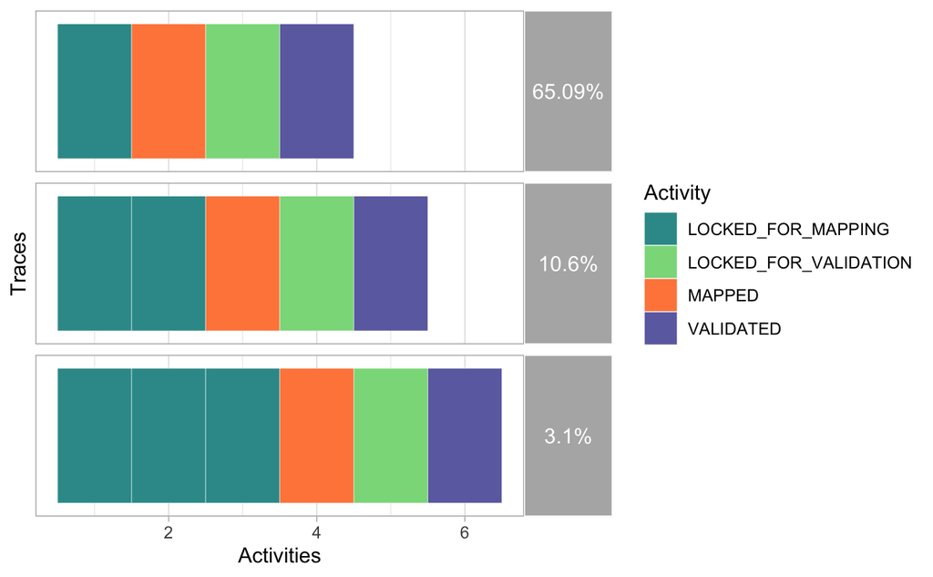

```r
event_log_df %>%    trace_explorer(n_traces = 3, show_labels = FALSE, coverage_labels = c("relative"))
```

# 2. Time

In the temporal process map, the value of nodes and edges represent the median duration in days of activities and waiting times.

```r
tmp1 <- tmp
tmp1 %>%  process_map(performance(median, "days"))
```

[interactive chart not shown]

Timestamps are properly formatted for time calculations

```r
event_log_df <- event_log_df %>% convert_timestamps(columns = c("start", "complete"), format = ymd_hms)
event_log_df$time_diff=as.numeric(event_log_df$complete-event_log_df$start)
task_duration <- event_log_df %>%  group_by(taskId) %>%  summarise(min = min(start), max= max(complete))
task_duration$duration=as.numeric(task_duration$max-task_duration$min)
task_duration <- task_duration[,c("taskId","duration")]
```

We calculated the relative time devoted for mapping activities (‘LOCKED_FOR_MAPPING’, ‘AUTO_UNLOCKED_FOR_MAPPING’) and validation activities (‘LOCKED_FOR_VALIDATION’,‘AUTO_UNLOCKED_FOR_VALIDATION’) per case expressed as percentage of total case duration. The remaining time is considered idle.

```r
mapping_duration <- filter(event_log_df, action == 'LOCKED_FOR_MAPPING' | action == 'AUTO_UNLOCKED_FOR_MAPPING') %>%  group_by(taskId) %>% summarise(mapping = sum(time_diff))
validation_duration <- filter(event_log_df, action == 'LOCKED_FOR_VALIDATION' | action == 'AUTO_UNLOCKED_FOR_VALIDATION') %>%  group_by(taskId) %>% summarise(validation = sum(time_diff))
durations <-  merge(x = merge(x = task_duration, y = mapping_duration, by = "taskId", all.x = TRUE), y = validation_duration, by = "taskId", all.x = TRUE)
durations[is.na(durations)] <- 0
durations$mapping_per=durations$mapping/durations$duration*100
durations$validation_per=durations$validation/durations$duration*100
durations$service=durations$mapping_per+durations$validation_per
durations$iddle_per=100-durations$mapping_per-durations$validation_per
```

Median % of iddle time per case

```r
median(durations$iddle_per, na.rm = TRUE )
```

```
[1] 99.93861
```

Median % of mapping and validation time per case

```r
median(durations$service, na.rm = TRUE )
```

```
[1] 0.06139425
```

Median % of mapping time per case

```r
median(durations$mapping_per, na.rm = TRUE )
```

```
[1] 0.01586283
```

Median % of validation time per case

```r
median(durations$validation_per, na.rm = TRUE )
```

```
[1] 0.02293203
```

# 3. Organisation

The contributor profile (“contributors.csv”) is added to the event log to calculate the relative frequency with which contributors according to their mapping level execute each type of activity.

```r
contributors <- read.csv("contributors.csv", stringsAsFactors = FALSE, sep = ",")
event_log_df <- merge(event_log_df, contributors, by.x = "actionBy", by.y = "username")
head(event_log_df)
```

|  | actionBy | X | taskId | action | start | complete | .order | time_diff | mappingLevel |
| --- | --- | --- | --- | --- | --- | --- | --- | --- | --- |
| 1 | Jean Yves Garinet | 897682 | 13680_57 | AUTO_UNLOCKED_FOR_MAPPING | 2022-10-30 20:47:58 | 2022-10-30 22:47:58 | 870604 | 7200.00000 | ADVANCED |
| 2 | Jean Yves Garinet | 1068988 | 14301_8 | LOCKED_FOR_MAPPING | 2023-03-23 20:27:36 | 2023-03-23 20:28:33 | 1032813 | 56.67504 | ADVANCED |
| 3 | Jean Yves Garinet | 1156728 | 14637_3465 | LOCKED_FOR_MAPPING | 2023-06-21 11:36:49 | 2023-06-21 11:37:33 | 1118289 | 43.79557 | ADVANCED |
| 4 | Jean Yves Garinet | 1156729 | 14637_3284 | LOCKED_FOR_MAPPING | 2023-06-21 11:36:49 | 2023-06-21 11:37:33 | 1118290 | 43.79557 | ADVANCED |
| 5 | Jean Yves Garinet | 1156727 | 14637_3303 | LOCKED_FOR_MAPPING | 2023-06-21 11:36:49 | 2023-06-21 11:37:33 | 1118288 | 43.79557 | ADVANCED |
| 6 | ____Melissa____ | 1046446 | 14235_1766 | AUTO_UNLOCKED_FOR_MAPPING | 2023-02-14 16:11:57 | 2023-02-14 18:11:57 | 1012664 | 7200.00000 | BEGINNER |

Composition of the total number of contributors of the analysed projects according to their mapping level.

```r
mappingLevel <- event_log_df %>%  group_by(mappingLevel) %>% summarise(count = n_distinct(actionBy))
mappingLevel$percentage <- round(mappingLevel$count/sum(mappingLevel$count)*100,1)
mappingLevel
```

| mappingLevel | count | percentage |
| --- | --- | --- |
| ADVANCED | 2219 | 6.7 |
| BEGINNER | 29921 | 90.7 |
| INTERMEDIATE | 852 | 2.6 |

Breakdown of status execution frequency per mapping level.

```r
data_pivot <- dcast(event_log_df, action ~ mappingLevel,value.var = "taskId", length)
data_pivot$sum <-  data_pivot$ADVANCED + data_pivot$BEGINNER + data_pivot$INTERMEDIATE
data_pivot$ADVANCEDper <- round(data_pivot$ADVANCED/data_pivot$sum*100,1)
data_pivot$BEGINNERper <- round(data_pivot$BEGINNER/data_pivot$sum*100,1)
data_pivot$INTERMEDIATEper <- round(data_pivot$INTERMEDIATE/data_pivot$sum*100,1)
data_pivot[c("action","ADVANCEDper","BEGINNERper","INTERMEDIATEper")] %>% gt() %>%  data_color(columns = 2:4, colors = col_numeric(palette = c("white","darkgreen"),domain = c(0,100)))
```

| action | ADVANCEDper | BEGINNERper | INTERMEDIATEper |
| --- | --- | --- | --- |
| AUTO_UNLOCKED_FOR_MAPPING | 19.2 | 74.4 | 6.4 |
| AUTO_UNLOCKED_FOR_VALIDATION | 96.0 | 1.8 | 2.2 |
| BADIMAGERY | 28.1 | 68.0 | 3.8 |
| EXTENDED_FOR_MAPPING | 96.1 | 3.3 | 0.6 |
| INVALIDATED | 94.3 | 2.6 | 3.1 |
| LOCKED_FOR_MAPPING | 42.5 | 50.7 | 6.7 |
| LOCKED_FOR_VALIDATION | 98.6 | 0.5 | 0.9 |
| MAPPED | 48.7 | 45.1 | 6.2 |
| SPLIT | 66.9 | 27.8 | 5.3 |
| VALIDATED | 98.9 | 0.3 | 0.8 |

# 4. Outcome

The regression.csv file contains the total list of tasks with columns describing either the absolute frequency of executions of each type of activity (“activityname”) or a binary flag (1/0) indicating whether or not the activity was executed (“activityname1”) on that task.

```r
regression <- read.csv("regression.csv", stringsAsFactors = FALSE, sep = ",")
regression$projId=as.character(regression$projId)
regression$percentage_area_covered_by_building = regression$percentage_area_covered_by_building / 100
#A few records have insignificant negative values attributed to rounding
regression$percentage_area_covered_by_building[regression$percentage_area_covered_by_building < 0] <- 0
regression = na.omit(regression)
```

Regression coefficients from the [GAMLSS-BEZI](https://www.rdocumentation.org/packages/gamlss.dist/versions/6.1-1/topics/BEZI) model

```r
model <- gamlss(percentage_area_covered_by_building ~ splits1 + invalidations1 + locked_for_mappings + badimagery1 + area_sqm + difficulty,  family = BEZI, data = regression, trace = F)
summary(model)
```

```
Family:  c("BEZI", "Zero Inflated Beta")

Call:  gamlss(formula = percentage_area_covered_by_building ~
    splits1 + invalidations1 + locked_for_mappings +
        badimagery1 + area_sqm + difficulty, family = BEZI,
    data = regression, trace = F)

Fitting method: RS()

------------------------------------------------------------------
Mu link function:  logit
Mu Coefficients:
                      Estimate Std. Error  t value Pr(>|t|)
(Intercept)         -3.490e+00  6.852e-03 -509.305   <2e-16 ***
splits1              4.414e-01  7.620e-03   57.924   <2e-16 ***
invalidations1       1.595e-01  1.102e-02   14.465   <2e-16 ***
locked_for_mappings  2.475e-02  1.026e-03   24.127   <2e-16 ***
badimagery1          2.744e-01  1.483e-02   18.505   <2e-16 ***
area_sqm            -1.363e-08  5.395e-10  -25.254   <2e-16 ***
difficultyEASY       8.706e-03  4.188e-03    2.079   0.0376 *
difficultyMODERATE  -3.100e-01  6.941e-03  -44.670   <2e-16 ***
---
Signif. codes:  0 ‘***’ 0.001 ‘**’ 0.01 ‘*’ 0.05 ‘.’ 0.1 ‘ ’ 1

------------------------------------------------------------------
Sigma link function:  log
Sigma Coefficients:
            Estimate Std. Error t value Pr(>|t|)
(Intercept)  1.78150    0.00534   333.6   <2e-16 ***
---
Signif. codes:  0 ‘***’ 0.001 ‘**’ 0.01 ‘*’ 0.05 ‘.’ 0.1 ‘ ’ 1

------------------------------------------------------------------
Nu link function:  logit
Nu Coefficients:
             Estimate Std. Error t value Pr(>|t|)
(Intercept) -0.527404   0.003707  -142.3   <2e-16 ***
---
Signif. codes:  0 ‘***’ 0.001 ‘**’ 0.01 ‘*’ 0.05 ‘.’ 0.1 ‘ ’ 1

------------------------------------------------------------------
No. of observations in the fit:  311808
Degrees of Freedom for the fit:  10
      Residual Deg. of Freedom:  311798
                      at cycle:  20

Global Deviance:     -1472183
            AIC:     -1472163
            SBC:     -1472057
```

Dropping model to single model terms

```r
drop1(model, parallel = "multicore", ncpus = 4)
```

```
Single term deletions for
mu

Model:
percentage_area_covered_by_building ~ splits1 + invalidations1 +
    locked_for_mappings + badimagery1 + area_sqm + difficulty
                    Df      AIC    LRT   Pr(Chi)
<none>                 -1472163
splits1              1 -1469065 3099.8 < 2.2e-16 ***
invalidations1       1 -1471958  206.8 < 2.2e-16 ***
locked_for_mappings  1 -1471626  538.8 < 2.2e-16 ***
badimagery1          1 -1471842  322.8 < 2.2e-16 ***
area_sqm             1 -1471379  786.2 < 2.2e-16 ***
difficulty           2 -1468601 3566.7 < 2.2e-16 ***
---
Signif. codes:  0 ‘***’ 0.001 ‘**’ 0.01 ‘*’ 0.05 ‘.’ 0.1 ‘ ’ 1
```

Describe percentage_area_covered_by_building for all projects

```r
regression$percentage_area_covered_by_building = regression$percentage_area_covered_by_building * 100
describe(regression$percentage_area_covered_by_building)
```

```
regression$percentage_area_covered_by_building
       n  missing distinct     Info     Mean      Gmd      .05      .10      .25
  311808        0   195041    0.949    1.909    3.294  0.00000  0.00000  0.00000
     .50      .75      .90      .95
 0.06499  0.92208  4.98023 11.29157

lowest : 0           1.11031e-14 1.11042e-14 1.11055e-14 1.11063e-14
highest: 96.982      98.676      99.1095     99.6358     99.8204
```

```r
sd(regression$percentage_area_covered_by_building, na.rm=TRUE)
```

```
[1] 5.568738
```

Display box-plot of percentage_area_covered_by_building for all projects

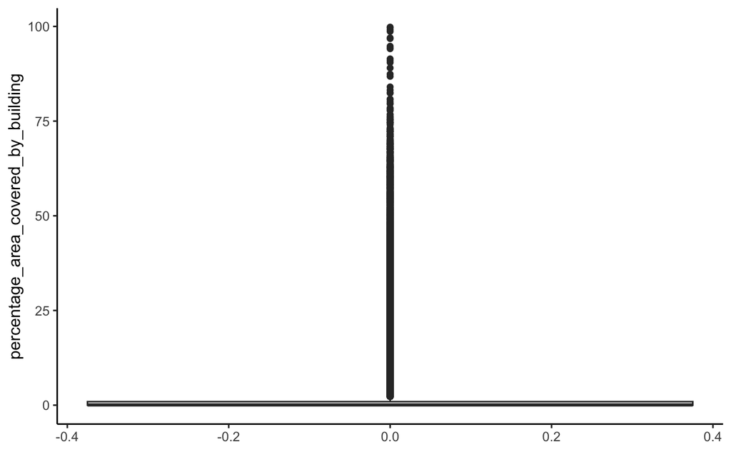

```r
p<-ggplot(regression, aes(y=percentage_area_covered_by_building)) +
  geom_boxplot()
p + theme_classic()
```

Describe percentage_area_covered_by_building by split category

```r
regression %>% group_by(splits1) %>% summarise(projId = n())
```

| splits1 | projId |
| --- | --- |
| 0 | 269775 |
| 1 | 42033 |

```r
tapply(regression$percentage_area_covered_by_building, regression$splits1, summary)
```

```
$`0`
    Min.  1st Qu.   Median     Mean  3rd Qu.     Max.
 0.00000  0.00000  0.05387  1.43866  0.74144 99.82039

$`1`
   Min. 1st Qu.  Median    Mean 3rd Qu.    Max.
 0.0000  0.0000  0.3152  4.9264  5.7893 72.9727
```

Display box-plot of percentage_area_covered_by_building by split category

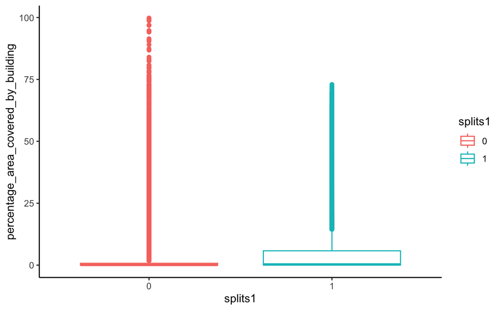

```r
regression$splits1=as.character(regression$splits1)
p<-ggplot(regression, aes(x=splits1, y=percentage_area_covered_by_building, color=splits1)) +
  geom_boxplot()
p + theme_classic()
```